# Comparison of Recount with GTEx

Andrew E. Jaffe and Kasper D. Hansen

July 18, 2016

# 1 Overview

This document compares GTEx data release v6 to Recount. The main issue addressed in this document is mapping up genes and samples between the two datasets. The annotations are different:

- GTEx uses Gencode v19 mapped to hg19.
- Recount uses Gencode v25 mapped to hg38, specifically this GFF3 file.

# 2 Dependencies

## 2.1 R packages

```r
library('ballgown')
library('coop')
library('org.Hs.eg.db')
library('readr')
library('recount')
library('rtracklayer')
library('stringr')
library('SummarizedExperiment')
library('limma')
library('edgeR')
```

## 2.2 Data objects

### 2.2.1 From Recount

### 2.2.2 From GTEx website

We have downloaded the annotation GTF files as well as the raw gene count matrix from the [GTEx portal](http://www.gtexportal.org).

```r
if(all(file.exists('gencode.v19.genes.patched_contigs.gtf', 'GTEx_Analysis_v6_RNA-seq_RNA-SeQCv1.1.8_gene_reads.gct.gz'))) {
    dataPath <- '.'
} else {
    dataPath <- "/dcs01/ajaffe/GTEX/V6" # wherever data was downloaded
}


gtexGtf <- import(file.path(dataPath, "gencode.v19.genes.patched_contigs.gtf"))
```

[output not shown]

[output not shown]

[output not shown]

[output not shown]

[output not shown]

[output not shown]

[output not shown]

[output not shown]

[output not shown]

[output not shown]

[output not shown]

[output not shown]

[output not shown]

[output not shown]

[output not shown]

[output not shown]

[output not shown]

[output not shown]

```r
gtexData <- read_tsv(file.path(dataPath,
    "GTEx_Analysis_v6_RNA-seq_RNA-SeQCv1.1.8_gene_reads.gct.gz"),
    skip = 2, progress = FALSE)
gtexCounts <- as.data.frame(gtexData[, 3:ncol(gtexData)])
rownames(gtexCounts) <- gtexData$Name
rm(gtexData)
```

### 2.2.3 From elsewhere

These are the the Rail-RNA processed samples

```r
if(!file.exists(file.path('SRP012682', 'rse_gene.Rdata'))) {
    download_study('SRP012682')
}
load('SRP012682/rse_gene.Rdata')
gtexPd <- colData(rse_gene)
```

Let’s match everything up.

```r
mm <- match(colnames(gtexCounts), gtexPd$sampid)
gtexCounts <- gtexCounts[, !is.na(mm)]
gtexPd <- gtexPd[mm[!is.na(mm)], ]
rse_gene <- rse_gene[, mm[!is.na(mm)]]
```

# 3 Mapping GTEx annotation

We map between version by using Ensembl gene IDs.

```r
## filter counts
geneMatch <- match(ballgown:::ss(rownames(gtexCounts), "\\."),
                ballgown:::ss(rowData(rse_gene)$gene_id, "\\."))
gtexCounts <- gtexCounts[!is.na(geneMatch),]
rse_gene <- rse_gene[geneMatch[!is.na(geneMatch)],]
## filter map
gtexMap <- gtexGtf[!duplicated(gtexGtf$gene_id)]
names(gtexMap) <- gtexMap$gene_id
gtexMap <- gtexMap[rownames(gtexCounts)]
gtexMap$EnsemblGeneID = ballgown:::ss(names(gtexMap), "\\.")

## Number of genes:
nrow(gtexCounts)
```

```
## [1] 51491
```

Let’s load data from Recount.

```r
rse_gene <- scale_counts(rse_gene)
recountCounts <- assays(rse_gene)$counts
recountMap <- rowRanges(rse_gene)
stopifnot(all(colnames(recountCounts) == rownames(gtexPd)))
```

# 4 Comparison

```r
gtexCounts <- as.matrix(gtexCounts)
ind <- which(colSums(is.na(gtexCounts)) == 0)
gtexCounts2 <- log2(sweep(gtexCounts, MARGIN = 2, FUN = "/",
    colSums(gtexCounts) / (4 * 10^7 )) + 1)[, ind]
recountCounts2 <- log2(recountCounts[, ind]+1)
gtexPd2 <- gtexPd[ind, ]
```

```r
normCors <- sapply(seq_len(nrow(gtexCounts2)),
    function(ii) pcor(gtexCounts2[ii, ],  recountCounts2[ii,]))
summary(normCors)
```

```
##    Min. 1st Qu.  Median    Mean 3rd Qu.    Max.    NA's
## -0.3011  0.7233  0.9420  0.8105  0.9858  1.0000     688
```

```r
sum(normCors <= 0.95, na.rm = TRUE)
```

```
## [1] 26591
```

```r
sum(normCors <= 0.80, na.rm = TRUE)
```

```
## [1] 15179
```

```r
mean(normCors >= 0.99, na.rm = TRUE)
```

```
## [1] 0.173848
```

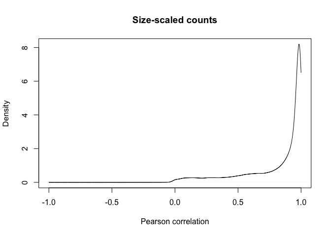

```r
dens <- density(normCors, from = -1, to = 1, na.rm = TRUE, n = 4096)
plot(dens, xlab = "Pearson correlation",
    main = "Size-scaled counts")
```

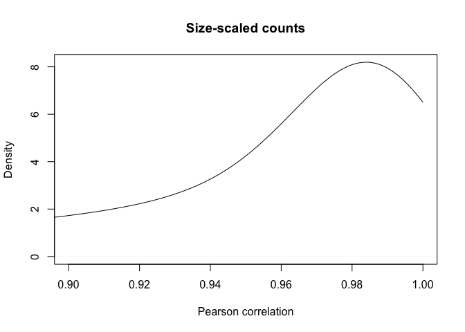

```r
plot(dens, xlab = "Pearson correlation",
     main = "Size-scaled counts", xlim = c(0.9,1))
```

```r
ind = which(gtexMap$gene_type == "protein_coding")
## Number of protein coding genes:
length(ind)
```

```
## [1] 18998
```

```r
normCors_coding <- sapply(seq_len(nrow(gtexCounts2[ind,])),
    function(ii) pcor(gtexCounts2[ind[ii], ],  recountCounts2[ind[ii],]))
summary(normCors_coding)
```

```
##    Min. 1st Qu.  Median    Mean 3rd Qu.    Max.    NA's
## -0.2345  0.9710  0.9874  0.9510  0.9932  0.9985       8
```

```r
sum(normCors_coding <= 0.95, na.rm = TRUE)
```

```
## [1] 3246
```

```r
sum(normCors_coding <= 0.80, na.rm = TRUE)
```

```
## [1] 1098
```

```r
mean(normCors_coding >= 0.99, na.rm = TRUE)
```

```
## [1] 0.3988415
```

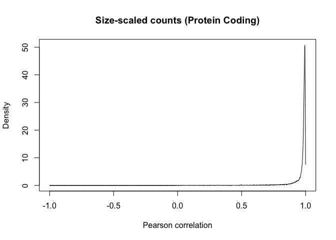

```r
dens <- density(normCors_coding, from = -1, to = 1, na.rm = TRUE, n = 4096)
plot(dens, xlab = "Pearson correlation",
    main = "Size-scaled counts (Protein Coding)")
```

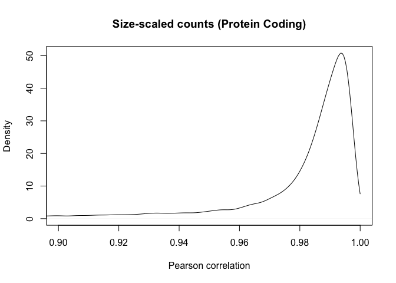

```r
plot(dens, xlab = "Pearson correlation",
     main = "Size-scaled counts (Protein Coding)", xlim = c(0.9,1))
```

# 5 Differential expression

Between colon and blood

```r
indTissue <- c(which(gtexPd2$smts == "Colon"),
    which(gtexPd2$smtsd == "Whole Blood"))
gtexPd2_sub <- gtexPd2[indTissue, ]
recountCounts2_sub <- recountCounts2[, indTissue]
gtexCounts2_sub <- gtexCounts2[,indTissue]
design <- model.matrix(~ smts , data = gtexPd2_sub)
```

Using recount:

```r
dge_recount <- DGEList(counts = recountCounts2_sub)
dge_recount <- calcNormFactors(dge_recount)
v_recount <- voom(dge_recount, design, plot=FALSE)
fit_recount <- lmFit(v_recount, design)
eb_recount <- ebayes(fit_recount)
out_recount <- data.frame(log2FC = fit_recount$coef[, 2],
    tstat = eb_recount$t[, 2], pvalue = eb_recount$p[, 2])
colnames(out_recount) <- paste0(colnames(out_recount), "_recount")
```

And using original counts:

```r
dge_gtex <- DGEList(counts = gtexCounts2_sub)
dge_gtex <- calcNormFactors(dge_gtex)
v_gtex <- voom(dge_gtex, design, plot=FALSE)
fit_gtex <- lmFit(v_gtex, design)
eb_gtex <- ebayes(fit_gtex)
out_gtex <- data.frame(log2FC = fit_gtex$coef[, 2],
    tstat = eb_gtex$t[, 2], pvalue = eb_gtex$p[, 2])
colnames(out_gtex) <- paste0(colnames(out_gtex), "_gtex")
```

Compare:

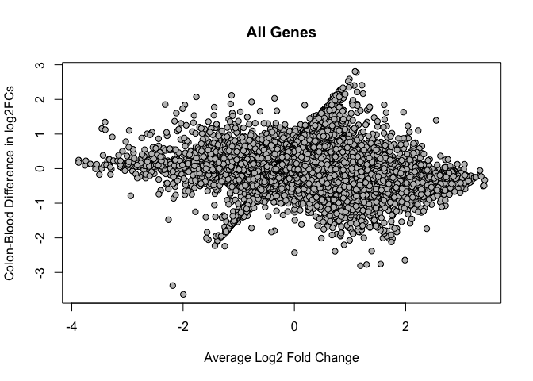

```r
M <- out_recount$log2FC_recount - out_gtex$log2FC_gtex
A <- ( out_recount$log2FC_recount + out_gtex$log2FC_gtex)/2
plot(M ~ A, xlab="Average Log2 Fold Change",
    ylab="Colon-Blood Difference in log2FCs",
    pch = 21, bg="grey", main = "All Genes")
```

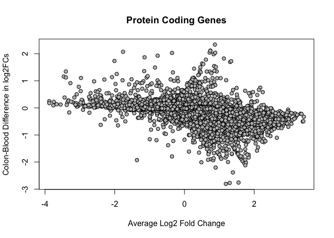

```r
plot(M ~ A, xlab="Average Log2 Fold Change", subset=ind,
    ylab="Colon-Blood Difference in log2FCs",
    pch = 21, bg="grey", main = "Protein Coding Genes")
```

```r
## Genes with M changes greater than 2
table(abs(M) > 2)
```

```
##
## FALSE  TRUE
## 51428    63
```

```r
round(table(abs(M) > 2) / length(M) * 100, 3)
```

```
##
##  FALSE   TRUE
## 99.878  0.122
```

```r
table(abs(M[ind]) > 2)
```

```
##
## FALSE  TRUE
## 18982    16
```

```r
round(table(abs(M[ind]) > 2) / length(ind) * 100, 3)
```

```
##
##  FALSE   TRUE
## 99.916  0.084
```

The R-squared is 0.8395661 for all 51491 genes and 0.916911 for all 18998 protein coding genes.

# 6 Reproducibility

This analysis report was made possible thanks to:

- R ([R Core Team, 2016](https://www.R-project.org/))
- *ballgown* (Fu, Frazee, Collado-Torres, Jaffe, et al., 2016)
- *BiocStyle* ([Oleś, Morgan, and Huber, 2017](https://github.com/Bioconductor/BiocStyle))
- *[coop](http://cran.fhcrc.org/web/packages/coop/index.html)* ([Schmidt, 2016](https://cran.r-project.org/package=coop))
- *[devtools](http://cran.fhcrc.org/web/packages/devtools/index.html)* ([Wickham and Chang, 2016](https://CRAN.R-project.org/package=devtools))
- *edgeR* (McCarthy, J., Chen, Yunshun, et al., 2012)
- *[knitcitations](http://cran.fhcrc.org/web/packages/knitcitations/index.html)* ([Boettiger, 2015](https://CRAN.R-project.org/package=knitcitations))
- *org.Hs.eg.db* (Carlson, 2016)
- *[readr](http://cran.fhcrc.org/web/packages/readr/index.html)* ([Wickham, Hester, and Francois, 2016](https://CRAN.R-project.org/package=readr))
- *recount* ([Collado-Torres, Nellore, Kammers, Ellis, et al., 2016](http://biorxiv.org/content/early/2016/08/08/068478))
- *[rmarkdown](http://cran.fhcrc.org/web/packages/rmarkdown/index.html)* ([Allaire, Cheng, Xie, McPherson, et al., 2017](http://rmarkdown.rstudio.com))
- *rtracklayer* ([Lawrence, Gentleman, and Carey, 2009](http://bioinformatics.oxfordjournals.org/content/25/14/1841.abstract))
- *[stringr](http://cran.fhcrc.org/web/packages/stringr/index.html)* ([Wickham, 2016](https://CRAN.R-project.org/package=stringr))
- *SummarizedExperiment* (Morgan, Obenchain, Hester, and Pagès, 2016)

Bibliography file

[1] J. Allaire, J. Cheng, Y. Xie, J. McPherson, et al. *rmarkdown: Dynamic Documents for R*. R package version 1.3. 2017. URL: http://rmarkdown.rstudio.com.

[2] C. Boettiger. *knitcitations: Citations for ‘Knitr’ Markdown Files*. R package version 1.0.7. 2015. URL: https://CRAN.R-project.org/package=knitcitations.

[3] M. Carlson. *org.Hs.eg.db: Genome wide annotation for Human*. R package version 3.4.0. 2016.

[4] L. Collado-Torres, A. Nellore, K. Kammers, S. E. Ellis, et al. “recount: A large-scale resource of analysis-ready RNA-seq expression data”. In: *bioRxiv* (2016). DOI: 10.1101/068478. URL: http://biorxiv.org/content/early/2016/08/08/068478.

[5] J. Fu, A. C. Frazee, L. Collado-Torres, A. E. Jaffe, et al. *ballgown: Flexible, isoform-level differential expression analysis*. R package version 2.7.0. 2016.

[6] M. Lawrence, R. Gentleman and V. Carey. “rtracklayer: an R package for interfacing with genome browsers”. In: *Bioinformatics* 25 (2009), pp. 1841-1842. DOI: 10.1093/bioinformatics/btp328. URL: http://bioinformatics.oxfordjournals.org/content/25/14/1841.abstract.

[7] McCarthy, D. J., Chen, Yunshun, et al. “Differential expression analysis of multifactor RNA-Seq experiments with respect to biological variation”. In: *Nucleic Acids Research* 40.10 (2012), pp. -9.

[8] M. Morgan, V. Obenchain, J. Hester and H. Pagès. *SummarizedExperiment: SummarizedExperiment container*. R package version 1.5.3. 2016.

[9] A. Oleś, M. Morgan and W. Huber. *BiocStyle: Standard styles for vignettes and other Bioconductor documents*. R package version 2.3.30. 2017. URL: https://github.com/Bioconductor/BiocStyle.

[10] R Core Team. *R: A Language and Environment for Statistical Computing*. R Foundation for Statistical Computing. Vienna, Austria, 2016. URL: https://www.R-project.org/.

[11] D. Schmidt. *Co-Operation: Fast Correlation, Covariance, and Cosine Similarity*. R package version 0.6-0. 2016. URL: https://cran.r-project.org/package=coop.

[12] H. Wickham. *stringr: Simple, Consistent Wrappers for Common String Operations*. R package version 1.1.0. 2016. URL: https://CRAN.R-project.org/package=stringr.

[13] H. Wickham and W. Chang. *devtools: Tools to Make Developing R Packages Easier*. R package version 1.12.0. 2016. URL: https://CRAN.R-project.org/package=devtools.

[14] H. Wickham, J. Hester and R. Francois. *readr: Read Tabular Data*. R package version 1.0.0. 2016. URL: https://CRAN.R-project.org/package=readr.

```r
## Time spent creating this report:
diff(c(timestart, Sys.time()))
```

```
## Time difference of 13.67401 mins
```

```r
## Date this report was generated
message(Sys.time())
```

```
## 2017-01-30 20:51:11
```

```r
## Reproducibility info
options(width = 120)
```

[output not shown]

```
## Packages ---------------------------------------------------------------------------------------------------------------
```

```
##  package              * version  date       source
##  acepack                1.4.1    2016-10-29 CRAN (R 3.4.0)
##  annotate               1.53.1   2016-12-27 Bioconductor
##  AnnotationDbi        * 1.37.1   2017-01-13 Bioconductor
##  assertthat             0.1      2013-12-06 CRAN (R 3.4.0)
##  backports              1.0.5    2017-01-18 CRAN (R 3.4.0)
##  ballgown             * 2.7.0    2016-10-23 Bioconductor
##  base64enc              0.1-3    2015-07-28 CRAN (R 3.4.0)
##  bibtex                 0.4.0    2014-12-31 CRAN (R 3.4.0)
##  Biobase              * 2.35.0   2016-10-23 Bioconductor
##  BiocGenerics         * 0.21.3   2017-01-12 Bioconductor
##  BiocParallel           1.9.5    2017-01-24 Bioconductor
##  BiocStyle            * 2.3.30   2017-01-27 Bioconductor
##  biomaRt                2.31.4   2017-01-13 Bioconductor
##  Biostrings             2.43.3   2017-01-24 Bioconductor
##  bitops                 1.0-6    2013-08-17 CRAN (R 3.4.0)
##  BSgenome               1.43.4   2017-01-20 Bioconductor
##  bumphunter             1.15.0   2016-10-23 Bioconductor
##  checkmate              1.8.2    2016-11-02 CRAN (R 3.4.0)
##  cluster                2.0.5    2016-10-08 CRAN (R 3.4.0)
##  codetools              0.2-15   2016-10-05 CRAN (R 3.4.0)
##  colorout             * 1.1-2    2016-11-15 Github (jalvesaq/colorout@6d84420)
##  colorspace             1.3-2    2016-12-14 CRAN (R 3.4.0)
##  coop                 * 0.6-0    2016-12-13 CRAN (R 3.4.0)
##  data.table             1.10.0   2016-12-03 CRAN (R 3.4.0)
##  DBI                    0.5-1    2016-09-10 CRAN (R 3.4.0)
##  derfinder              1.9.6    2017-01-13 Bioconductor
##  derfinderHelper        1.9.3    2016-11-29 Bioconductor
##  devtools               1.12.0   2016-12-05 CRAN (R 3.4.0)
##  digest                 0.6.12   2017-01-27 CRAN (R 3.4.0)
##  doRNG                  1.6      2014-03-07 CRAN (R 3.4.0)
##  downloader             0.4      2015-07-09 CRAN (R 3.4.0)
##  edgeR                * 3.17.5   2016-12-13 Bioconductor
##  evaluate               0.10     2016-10-11 CRAN (R 3.4.0)
##  foreach                1.4.3    2015-10-13 CRAN (R 3.4.0)
##  foreign                0.8-67   2016-09-13 CRAN (R 3.4.0)
##  Formula                1.2-1    2015-04-07 CRAN (R 3.4.0)
##  genefilter             1.57.0   2016-10-23 Bioconductor
##  GenomeInfoDb         * 1.11.6   2016-11-17 Bioconductor
##  GenomicAlignments      1.11.8   2017-01-24 Bioconductor
```

[output cut: 53 more lines]

```
##  S4Vectors            * 0.13.11  2017-01-28 cran (@0.13.11)
##  scales                 0.4.1    2016-11-09 CRAN (R 3.4.0)
##  stringi                1.1.2    2016-10-01 CRAN (R 3.4.0)
##  stringr              * 1.1.0    2016-08-19 CRAN (R 3.4.0)
##  SummarizedExperiment * 1.5.3    2016-11-11 Bioconductor
##  survival               2.40-1   2016-10-30 CRAN (R 3.4.0)
##  sva                    3.23.0   2016-10-23 Bioconductor
##  tibble                 1.2      2016-08-26 CRAN (R 3.4.0)
##  VariantAnnotation      1.21.15  2017-01-20 Bioconductor
##  withr                  1.0.2    2016-06-20 CRAN (R 3.4.0)
##  XML                    3.98-1.5 2016-11-10 CRAN (R 3.4.0)
##  xtable                 1.8-2    2016-02-05 CRAN (R 3.4.0)
##  XVector                0.15.1   2017-01-24 Bioconductor
##  yaml                   2.1.14   2016-11-12 CRAN (R 3.4.0)
##  zlibbioc               1.21.0   2016-10-23 Bioconductor
```